# Prosper Loan Data Analysis with R

# Introduction

#### I have chosen to analyze this dataset, because I want to investigate the nature of how Prosper loans are assessed for risk. I’ll first take a general look at the dataset to get a feel for a few variables of interest, then I will check for relationships between these variables.

#### My ultimate goal is to see what generally affects the rate and loan amount.

# Univariate Section

### Quick Overview of Several Variables in the Dataset.

#### Most of the loans in this dataset are given to employed individuals who have a Prosper score that ranges between 4 to 8; a lower-range credit score between 660 and 720; and an upper-range credit score between 679 and 739.

```r
summary(data$EmploymentStatus)
```

```
##                    Employed     Full-time Not available  Not employed
##          2255         67322         26355          5347           835
##         Other     Part-time       Retired Self-employed
##          3806          1088           795          6134
```

```r
summary(data$ProsperScore)
```

```
##    Min. 1st Qu.  Median    Mean 3rd Qu.    Max.    NA's
##    1.00    4.00    6.00    5.95    8.00   11.00   29084
```

```r
summary(data$CreditScoreRangeLower)
```

```
##    Min. 1st Qu.  Median    Mean 3rd Qu.    Max.    NA's
##     0.0   660.0   680.0   685.6   720.0   880.0     591
```

```r
summary(data$CreditScoreRangeUpper)
```

```
##    Min. 1st Qu.  Median    Mean 3rd Qu.    Max.    NA's
##    19.0   679.0   699.0   704.6   739.0   899.0     591
```

```r
summary(data$DebtToIncome)
```

```
##    Min. 1st Qu.  Median    Mean 3rd Qu.    Max.    NA's
##   0.000   0.140   0.220   0.276   0.320  10.010    8554
```

```r
describe(data$DebtToIncome)
```

```
##   vars      n mean   sd median trimmed  mad min   max range  skew kurtosis
## 1    1 105383 0.28 0.55   0.22    0.23 0.12   0 10.01 10.01 15.44   261.31
##   se
## 1  0
```

```r
summary(data$DelinquenciesLast7Years)
```

```
##    Min. 1st Qu.  Median    Mean 3rd Qu.    Max.    NA's
##   0.000   0.000   0.000   4.155   3.000  99.000     990
```

```r
summary(data$InquiriesLast6Months)
```

```
##    Min. 1st Qu.  Median    Mean 3rd Qu.    Max.    NA's
##   0.000   0.000   1.000   1.435   2.000 105.000     697
```

```r
summary(data$CreditScoreRangeUpper)
```

```
##    Min. 1st Qu.  Median    Mean 3rd Qu.    Max.    NA's
##    19.0   679.0   699.0   704.6   739.0   899.0     591
```

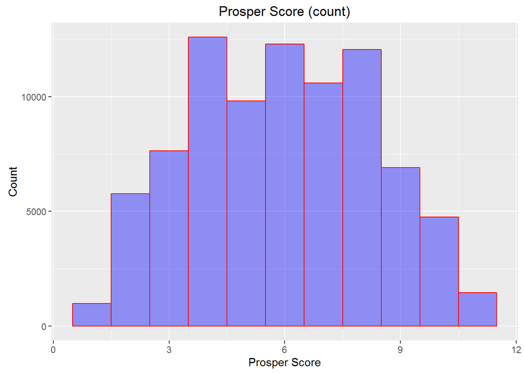

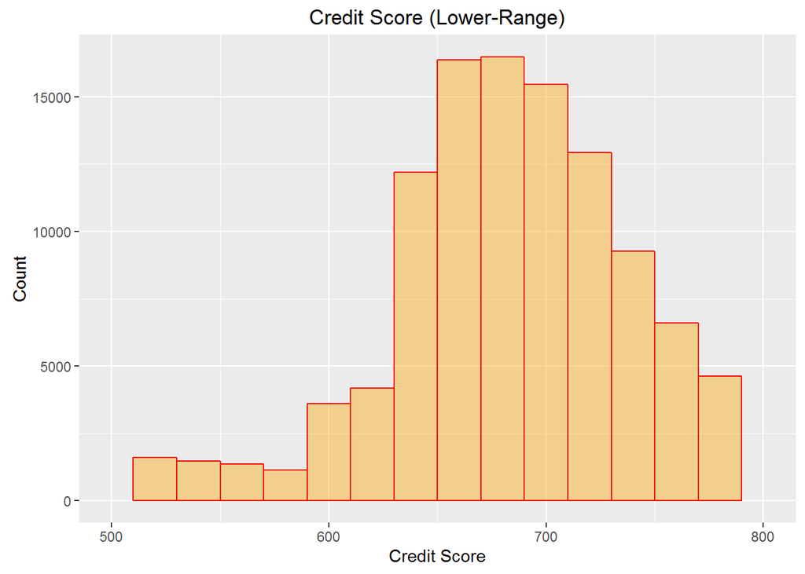

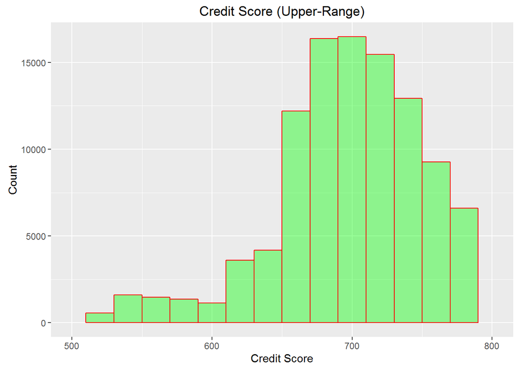

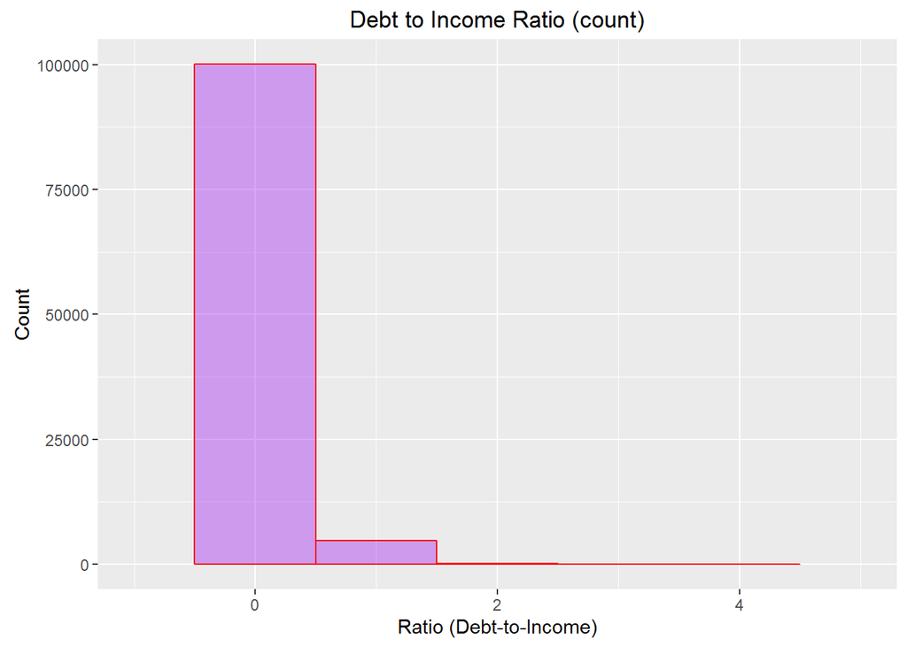

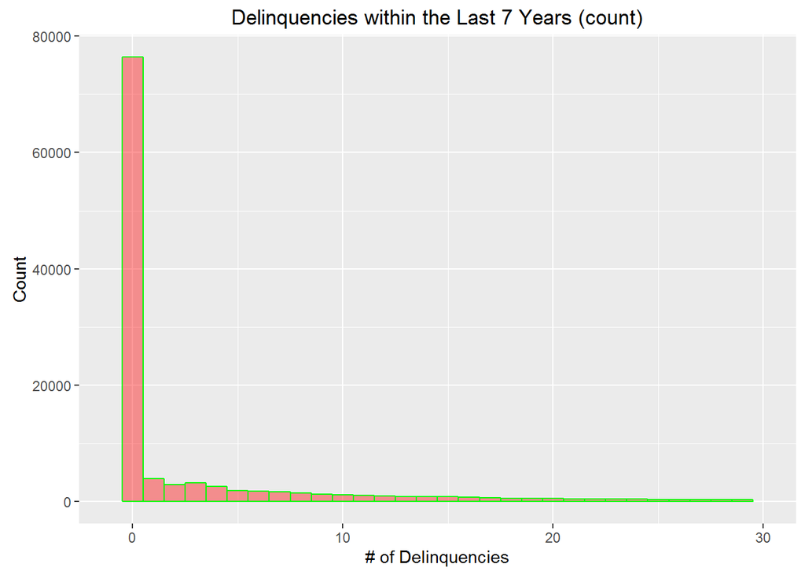

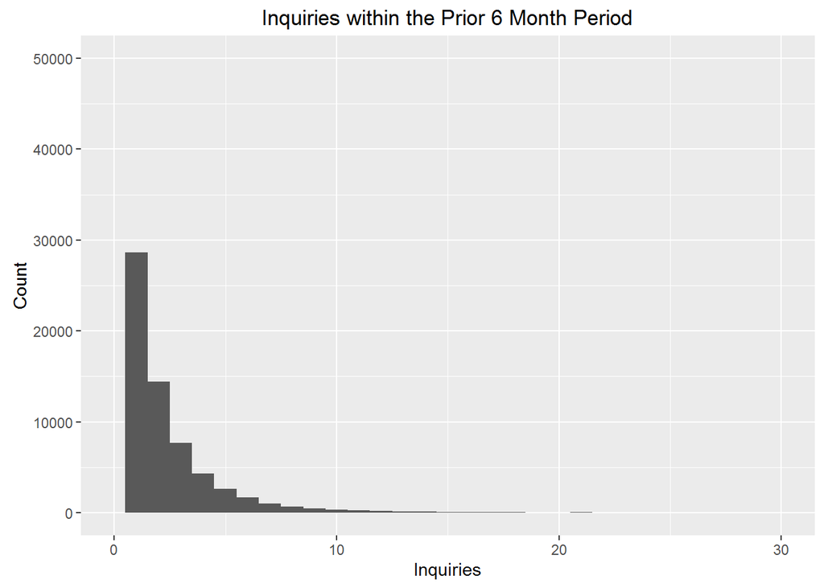

#### The most common loans are $4,000 in a 36-month term and are supported by one investor each.

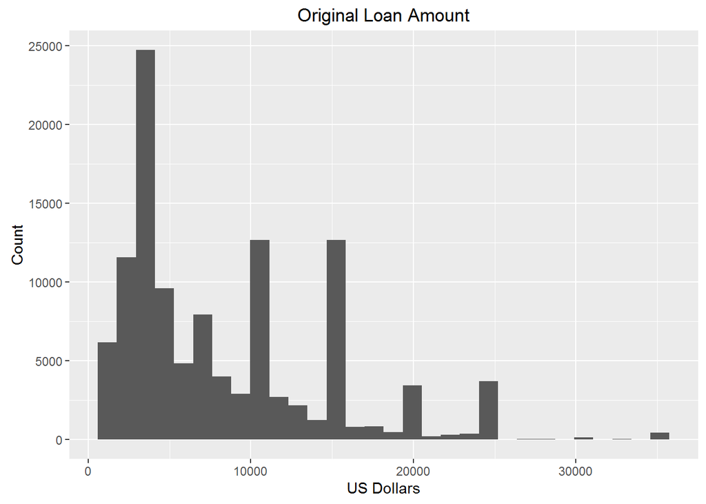

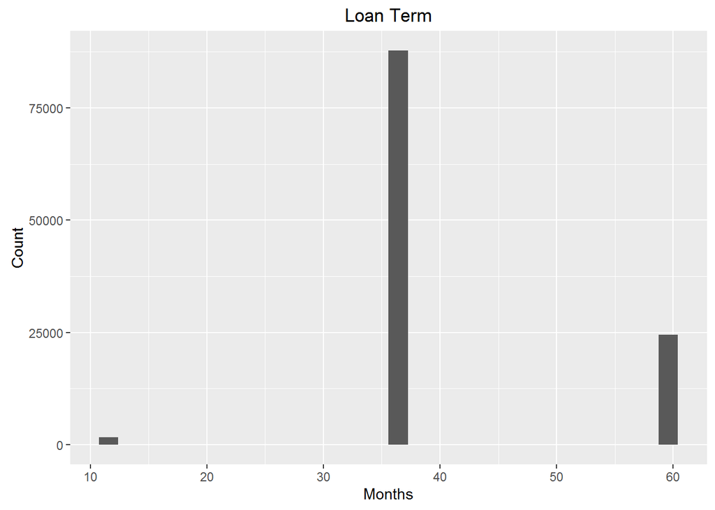

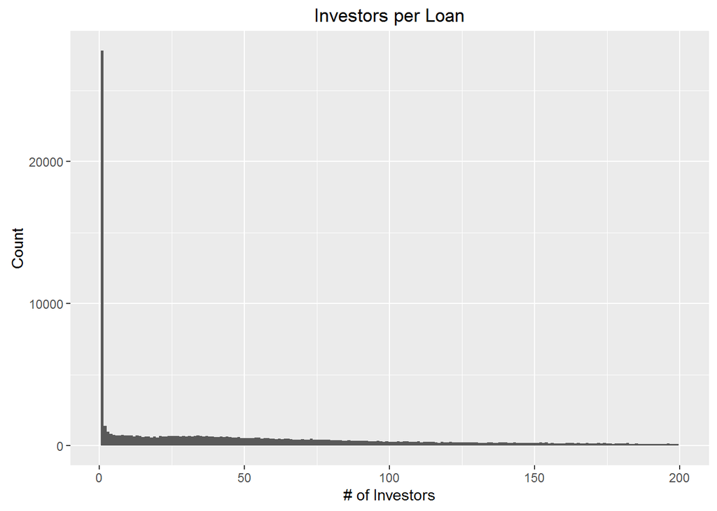

#### The average loan payment is $272.5/month, but the most common is about $173.71/month.

```
##    Min. 1st Qu.  Median    Mean 3rd Qu.    Max.
##     0.0   131.6   217.7   272.5   371.6  2252.0
```

```
## [1] "173.71"
```

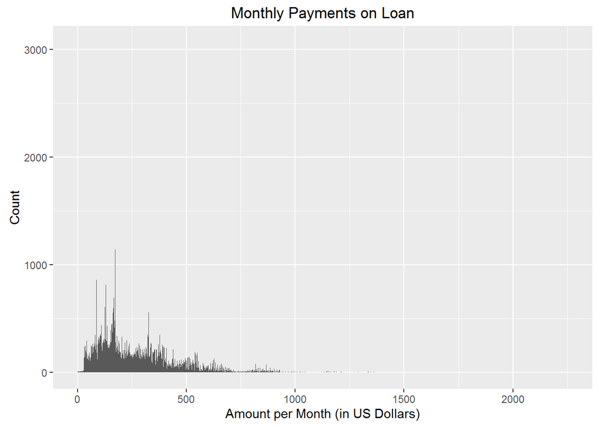

#### Most loans are taken by individuals who listed their occupation as “other” and “professional.”

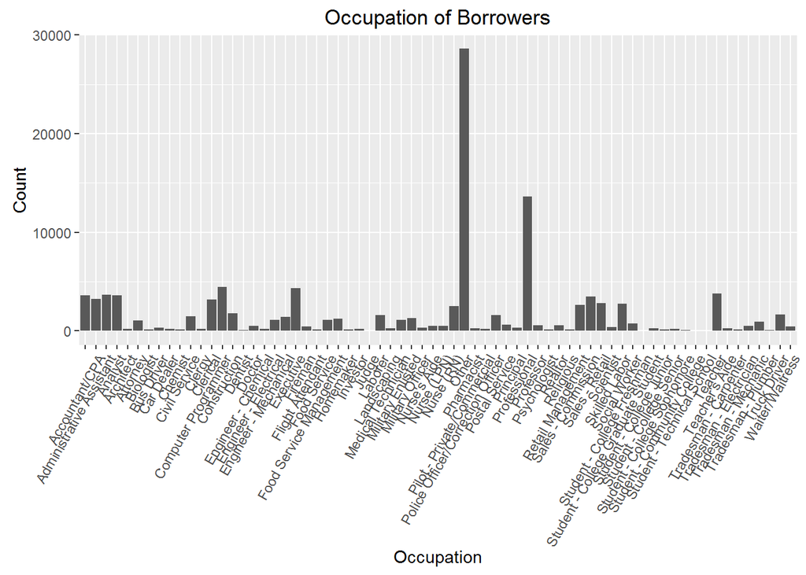

#### Unemployed individuals also received loans. In the bivariate section, I’ll compare the loan amount given to unemployed individuals versus those who are employed.

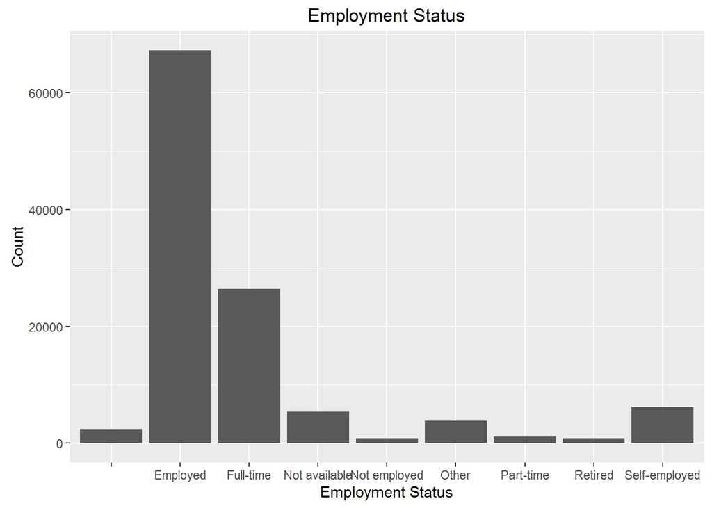

# Univariate Analysis

### What is the structure of your dataset?

#### There are 113,937 loans in the dataset with 81 variables, such as Prosper score, credit score, delinquencies in the last 7 years, open credit lines, and so on.

### What is/are the main feature(s) of interest in your dataset?

#### I am investigating the factors that affect the borrower rate and loan amount. I figure that I should first understand what factors affect the Prosper Score, so my interests are the Prosper score, credit scores, delinquencies, occupations, employment statuses, income, borrowers’ rate, APR, and original loan amount.

### What other features in the dataset do you think will help support your investigation into your feature(s) of interest?

#### The other items that could help support my investigation are the revolving credit balance, the individual’s homeownership status, and the individual’s public records within the past 10 years. I assume that since people grant other people loans, then that must mean that a level of human judgement, regarding the overall trustworthiness of an individual, helps decide what amount the individual will be granted and how much the interest rate and APR will be.

### Did you create any new variables from existing variables in the dataset?

#### Not in this section; however, it was tempting to mess with the income range variable.

### Of the features you investigated, were there any unusual distributions? Did you perform any operations on the data to tidy, adjust, or change the form of the data? If so, why did you do this?

#### I haven’t observed any unusual distributations yet.

# Bivariate Plots Section

#### How much of an affect does the Prosper score have on the individual’s loan application? And what can the Prosper score tell us about the lenders and the borrowers? Can the data show us its affects, if we compare it to one variable at a time?

#### Let’s first take a look at the potential effects of the Prosper score on the loan approval process.

#### Does the Prosper score affect the amount of loan given to borrowers?

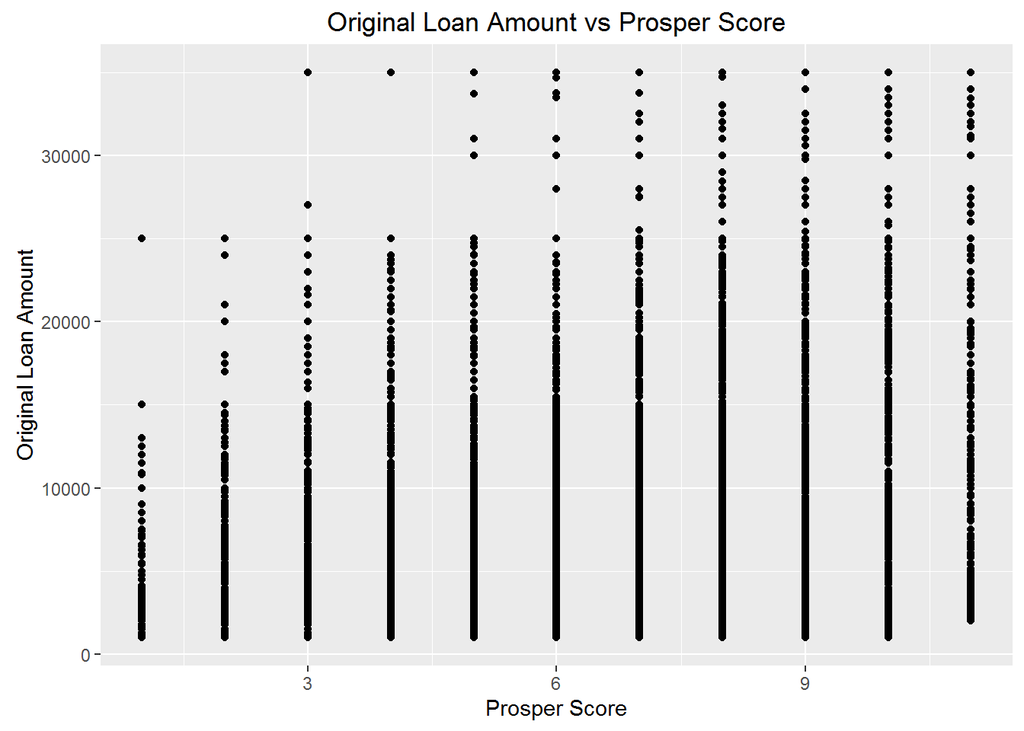

#### It appears that there may be a pattern.

#### Momentarily disregarding the slight odd cases under each Prosper score,-which we could consider as a type of conditional disturbance in a potential trend,-we observe for the pattern in the highest concentrated areas:

*Prosper score 1: $10,000*  
Prosper score 2: $15,000  
*Prosper score 3: $20,000*  
Prosper score 4: $25,000  
*Prosper score 5: $25,000*  
Prosper score 6: $25,000  
*Prosper score 7: $25,000*  
Prosper score 8: $25,000  
*Prosper score 9: $25,000*  
Prosper score 10: $25,000

#### There’s not that much of a pattern here. It could be that people with higher Prosper scores allow themselves to take bigger loans due to their better conditions for paying it back. But taking another look at this data may give more insight into possible underlying patterns.

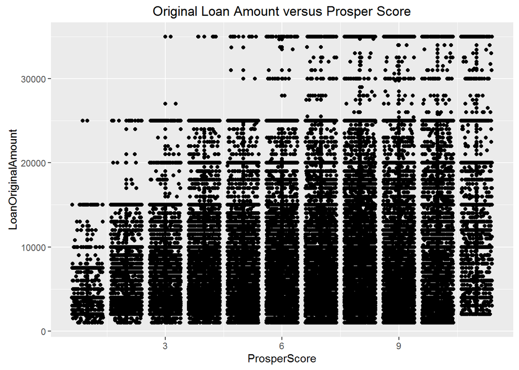

#### Now it’s more apparent that most loans in this data are taken in $1,000 multiples, with $15,000 as the most common upper amount, and with $25,000 following. This means that we might not be able to extract much information from the loan amount, since, from score 3 and up, it’s possible to get a $35,000 loan.

#### Does the Prosper score have an effect on the borrower’s APR and rate?

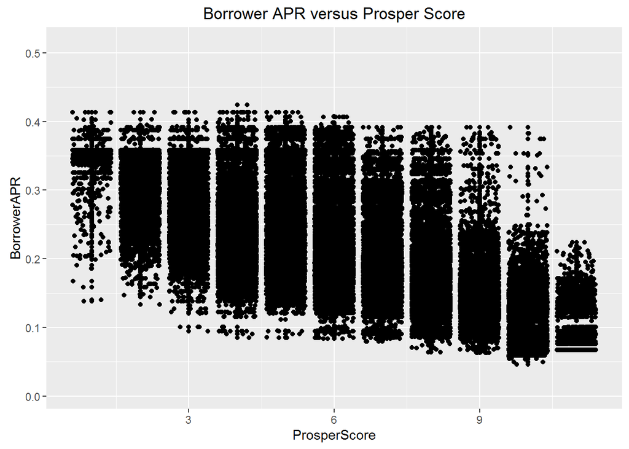

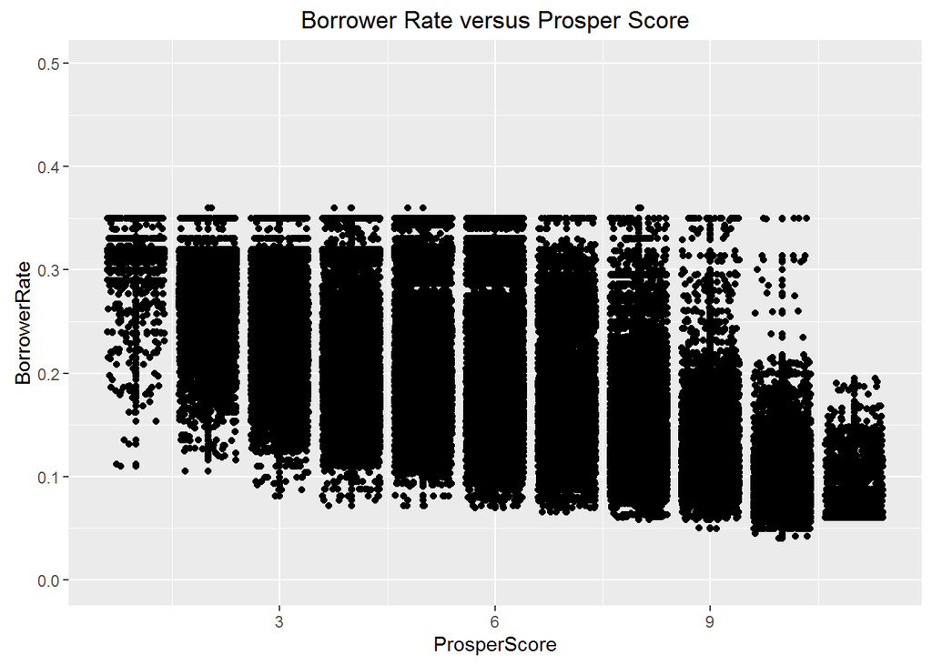

#### Here is the first major sign of the Prosper score showing a relationship to the loans. The higher the Prosper score, the lower the borrower APR and rate. But of course, as it is common knowledge, we know that the better credit history an individual has, the more trustworthy he/she becomes to lenders. And the Prosper score is a risk score based on historical Prosper data. But we also know that we haven’t yet seen evidence of it being related to the credit score of the individual.

#### So is it safe to say that, in order to get a good, low APR and rate on a Prosper loan, then one must have a high Prosper score? Well, let’s find out what else might be affecting the borrower APR and rate.

#### Could the credit score be affecting them?

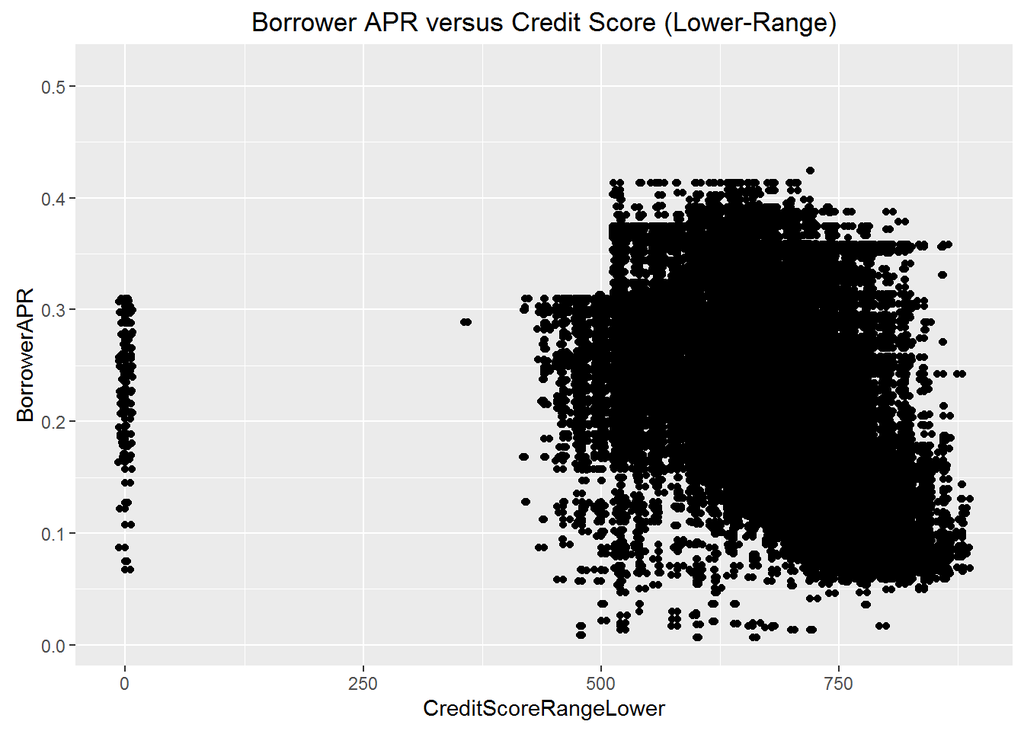

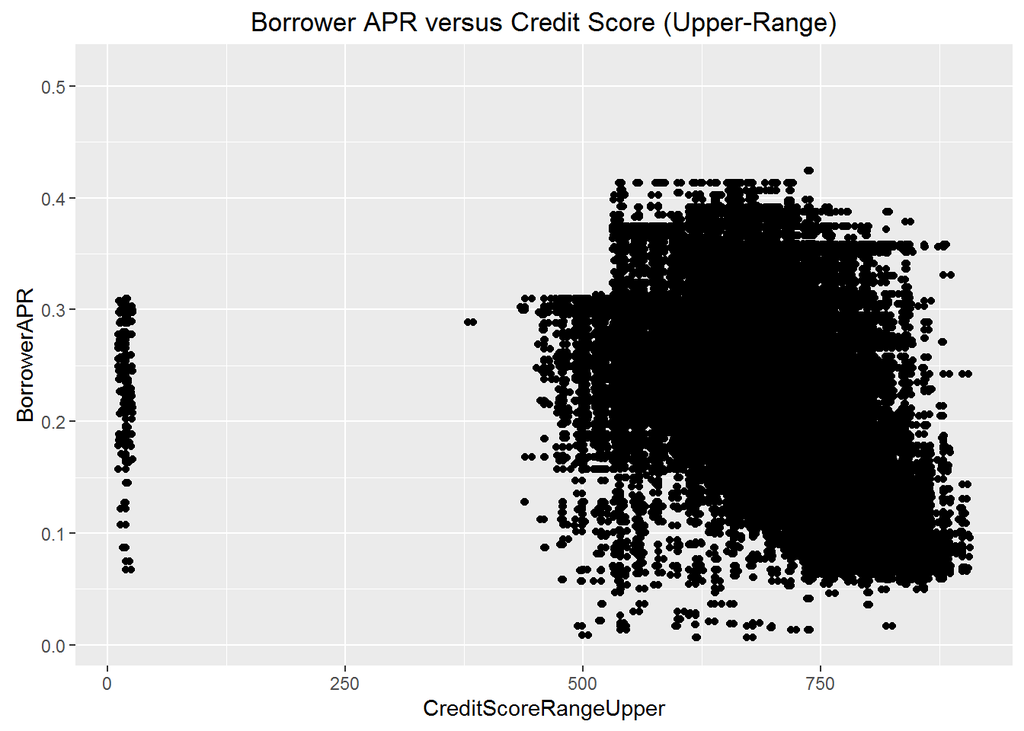

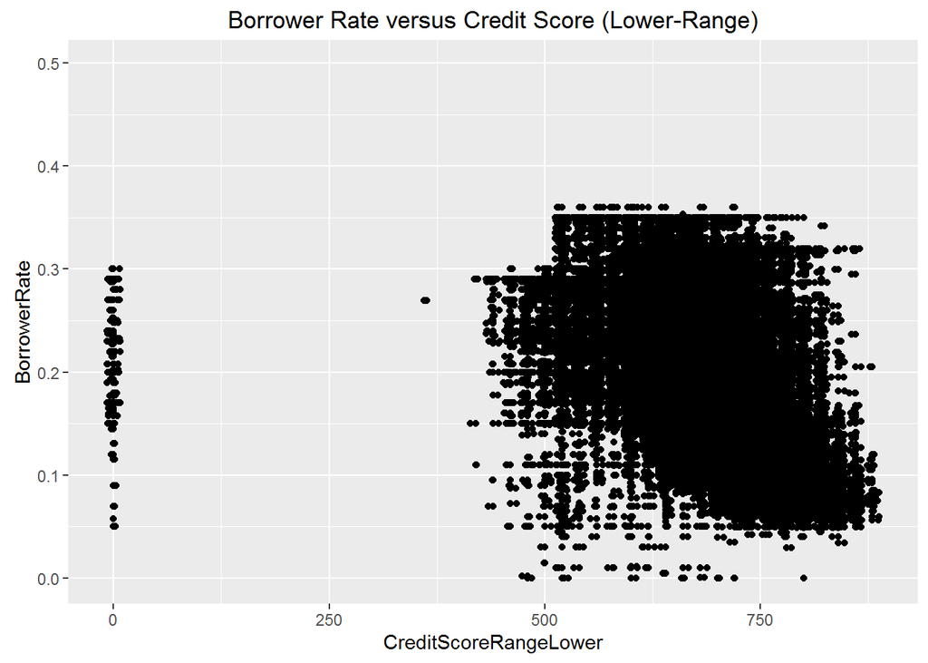

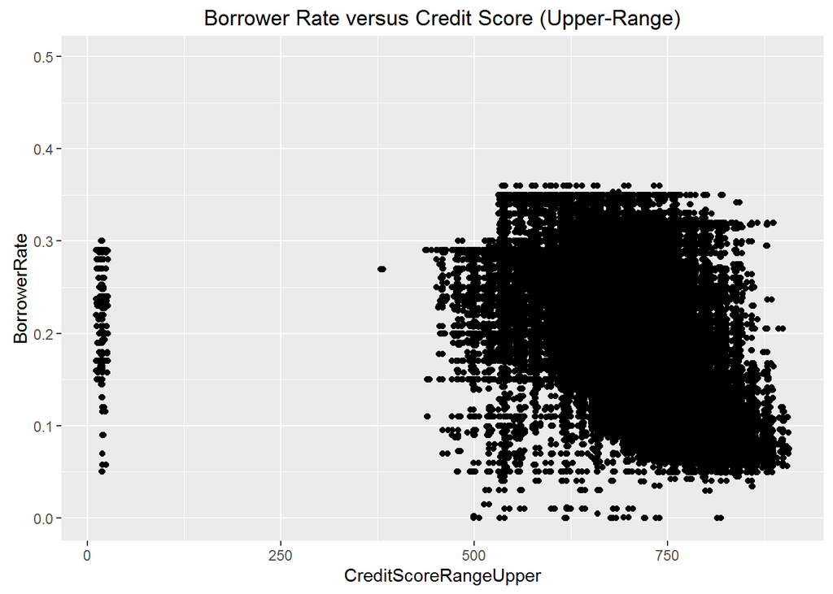

#### Yes, but something looks a bit odd about it. The patterns are not as clear and consistent as when comparing to the Prosper score. So it’s probably safe to say that the Prosper score is a better measure for what the borrower APR and rate will be like.

#### So then what affects the Prosper score? Does the employment status show to affect it?

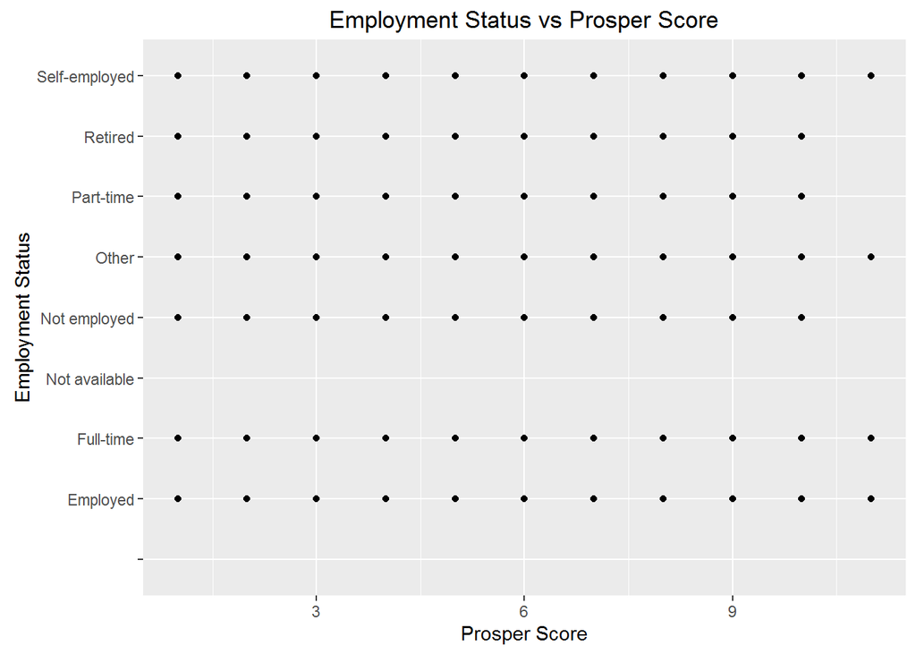

#### Employment status shows to not affect the Prosper score; at least not signficantly. We could add a bit of noise to have a better look, and who knows, it might reveal something good, but there are other ways to look at this, so I’ll move on for now.

#### Does income have an effect on the Prosper score?

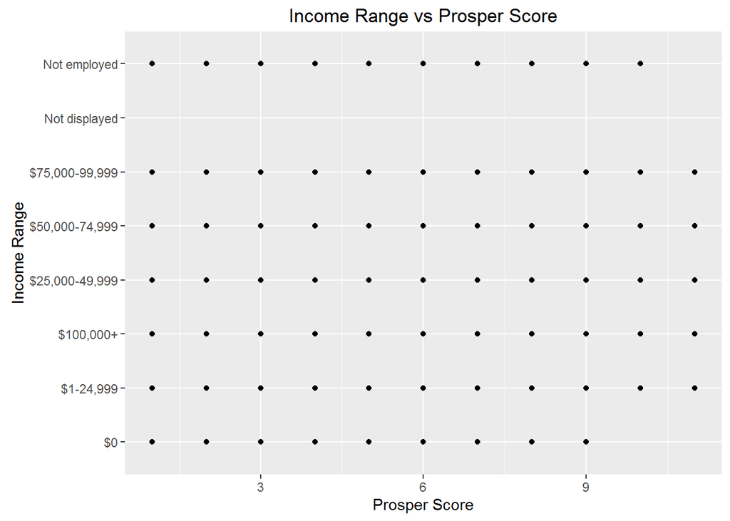

#### Income range does not appear to have any absolute effects on the Prosper score; although, there may be an exception with a Prosper score of 10. But it could just be that no one in this dataset with an income range of $0 has a Prosper score of 10. So, at this time, and in this view, we can rule income range out as a significant variable, until we take another look at it later.

#### We should pay attention to the relationship between the income range and the original loan amount. Perhaps, we should even quickly take a look to see if homeowners are treated differently here.

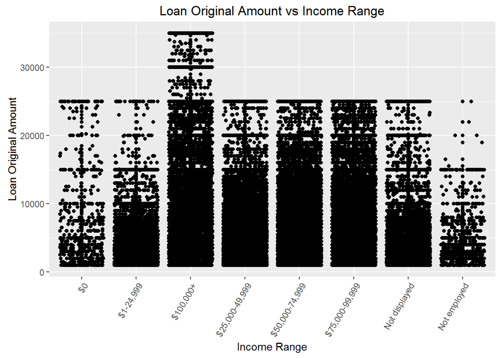

#### Well, here, we can observe something satisfying to the eye: only those who made over $100,000/year received loans over $25,000. It’s also notable that we can add this plot to the evidence for the fact that those with the unemployed status received less amounts.

#### Let’s briefly take a closer look just to further analyze the relevance of the Prosper score to the original loan amount.

```
##    Min. 1st Qu.  Median    Mean 3rd Qu.    Max.    NA's
##   1.000   5.000   7.000   6.738   9.000  11.000    2132
```

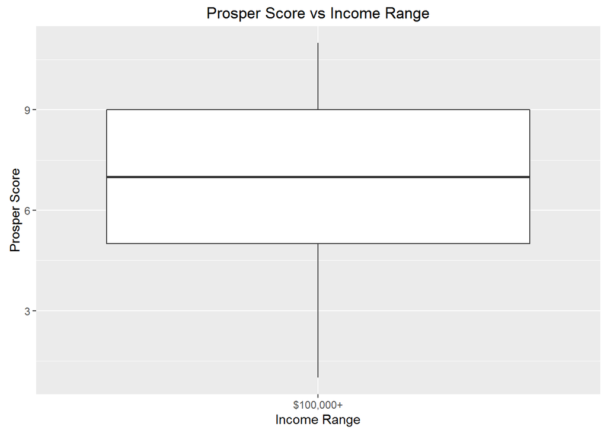

#### This is some good detail that was not apparent in the earlier plots. In this case, we must also observe the lower income range to see if the Prosper score proves to be different. If not, then we can rule income range out for good in my investigation.

```
##    Min. 1st Qu.  Median    Mean 3rd Qu.    Max.    NA's
##   1.000   4.000   5.000   5.093   7.000  11.000    2620
```

```
##    Min. 1st Qu.  Median    Mean 3rd Qu.    Max.    NA's
##   1.000   5.000   7.000   6.738   9.000  11.000    2132
```

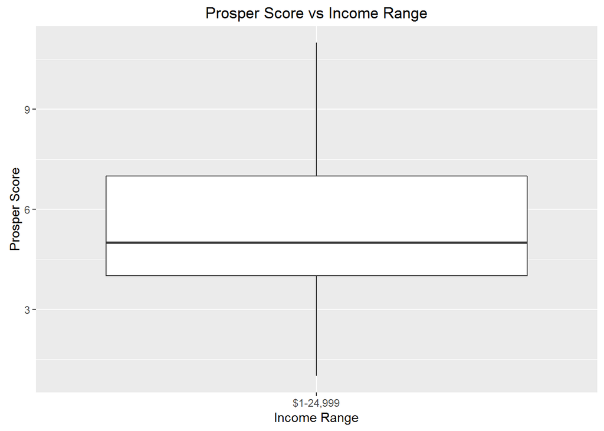

#### We may now assume that earning over $100,000/year will earn about 2 points on the Prosper score, since the difference between the average of the lower incomes and the higher incomes is about almost two points; whereas, the median and 3rd quartile are exactly 2 points away. That was a slight surprise. I think that I was ready to rule income out far too early. It could also be that there are 81 variables in this dataset and I am eager to look through many of them.

#### Let’s see if occupation shows any trends in the Prosper score:

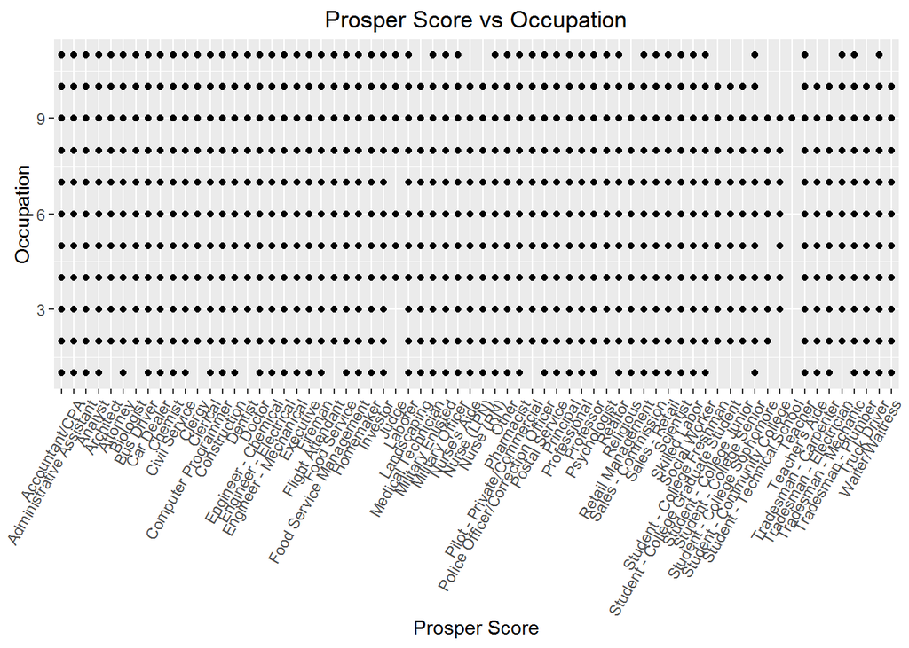

#### There seems to be nothing significant with occupation. It looks like nearly anyone with any occupation could have a high or low Prosper score. The little bit of differences seen in the plot are most likely due to the dataset not having more individuals of those occupations. So it’s probably a matter of the dataset itself, as opposed to the relationships in the data.

#### Are credit-seekers discriminated against in the Prosper scoring system?

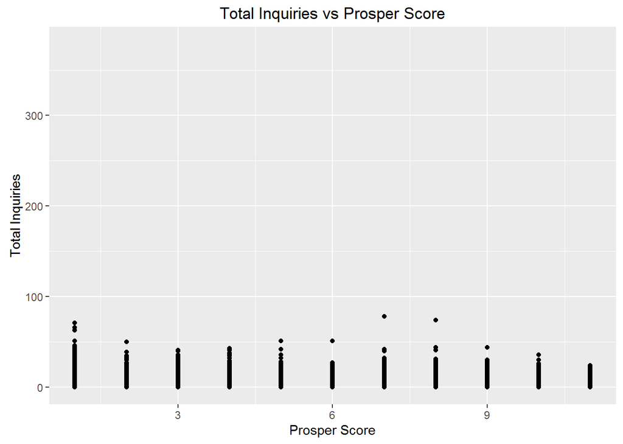

#### It doesn’t look like a significant difference. It looks a bit wavy and rules the idea out from this perspective.

#### How about delinquencies in the past 7 years?

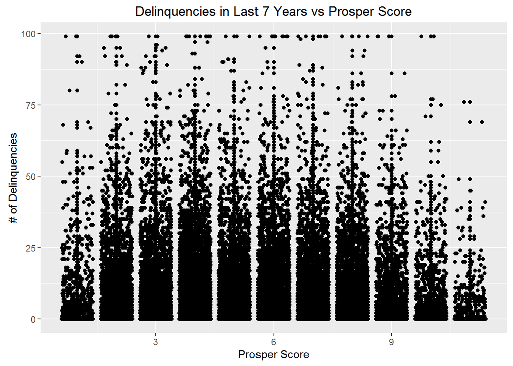

#### The curve in this graph renders that idea useless, as one would easily expect that the number of delinquencies within a 7-year period would continuously decrease along the Prosper scores, from lowest to highest. The reasoning is that those who were able to obtain a higher Prosper score were those who were able to make their payments on time throughout the years; however, that does not seem to be the case here.

#### Now let’s go back to employment status, since we found something interesting earlier. The unemployed individuals in the dataset have loans anywhere between $1,000 to $25,000. Most are $4,000.